# Social Cross-Situational Word Learning

Kyle MacDonald & Allison Dods

July 14, 2014

TODO: - relable RT – test and exposure columns - reorder gazeLength factor levels for plots

Analysis code for SOC-XSIT project.

Load libraries.

```r
library(bootstrap)
library(lme4)
library(ggplot2)
library(arm)
library(directlabels)
library(stringr)
library(plyr)
library(reshape2)
library(car)
library(dplyr)
library(xtable)
source("/Users/kmacdonald/Documents/Projects/SOC_XSIT/XSIT-MIN/analysis/Ranalysis/useful.R")
```

Read in data. - d is the first pilot (manipulated gaze length, 4-referents, 0 delay) - d1 is the second pilot (just ran the short gaze condition and added the no-social condition )

```r
d <- read.csv("/Users/kmacdonald/Documents/Projects/SOC_XSIT/processed_data/soc_xsit_4_looks_pilot.csv")
d1 <- read.csv("/Users/kmacdonald/Documents/Projects/SOC_XSIT/processed_data/soc_xsit_4_looks_pilot_2.csv")
```

Get the number of subjects in each condition.

```
##   gazeLength condition freq
## 1       Long    Social   48
## 2     Medium    Social   50
## 3      Short    Social   46
```

```
##   gazeLength condition freq
## 1      Short No-social   51
## 2      Short    Social   47
```

Subset pilot 1 data for analysis.

```r
d.test <- subset(d, testTrial==1)                               # test trials
d.first.trial <- subset(d, testTrial==1 & first.trial==TRUE)    # first test trial for each sub
d.exp <- subset(d, exposureTrial==1)                            # exposure trials
```

Did subjects choose target of gaze on exposure trials?

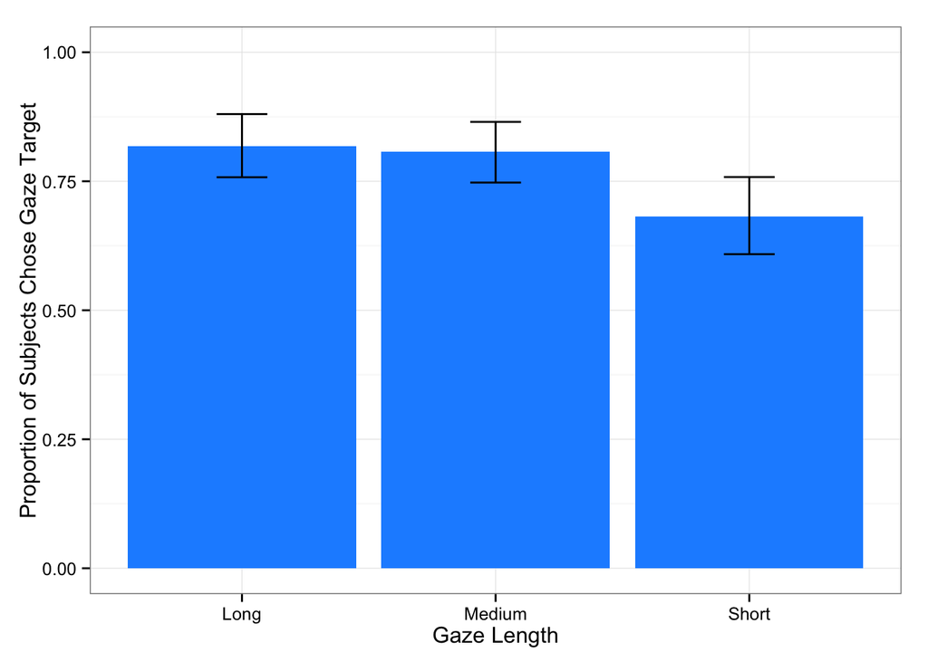

Now subset test trials to include only those on which participants chose the target of gaze on exposure.

```r
d.choseSocial <- subset(d.exp, select=c("subid", "itemNum",
                                        "choseSocial", "rt"))   # exposure trials chose gazeTar

d.test.gazeTar <- merge(d.test, d.choseSocial,
                             by=c("subid", "itemNum"),
                             all=TRUE)                          # test trials with exp trial info

d.test.choseGazeTar <- subset(d.test.gazeTar,
                              choseSocial == TRUE,
                              select=c(subid:rt.y))             # test trils: just chose gazeTar on exp
```

Clean out trials with extremely slow RTs (+/- 2SD).

```r
d.test.choseGazeTar$correct[log(d.test.choseGazeTar$rt.x) > mean(log(d.test.choseGazeTar$rt.x)) + 2* sd(log(d.test.choseGazeTar$rt.x)) | log(d.test.choseGazeTar$rt.x) < mean(log(d.test.choseGazeTar$rt.x)) - 2* sd(log(d.test.choseGazeTar$rt.x))] <- NA
```

Accuracy on test trials (Same/Switch).

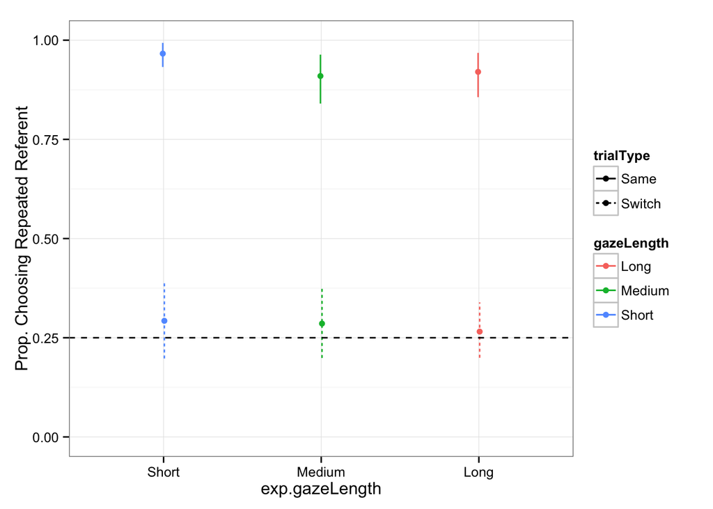

RT on exposure trials.

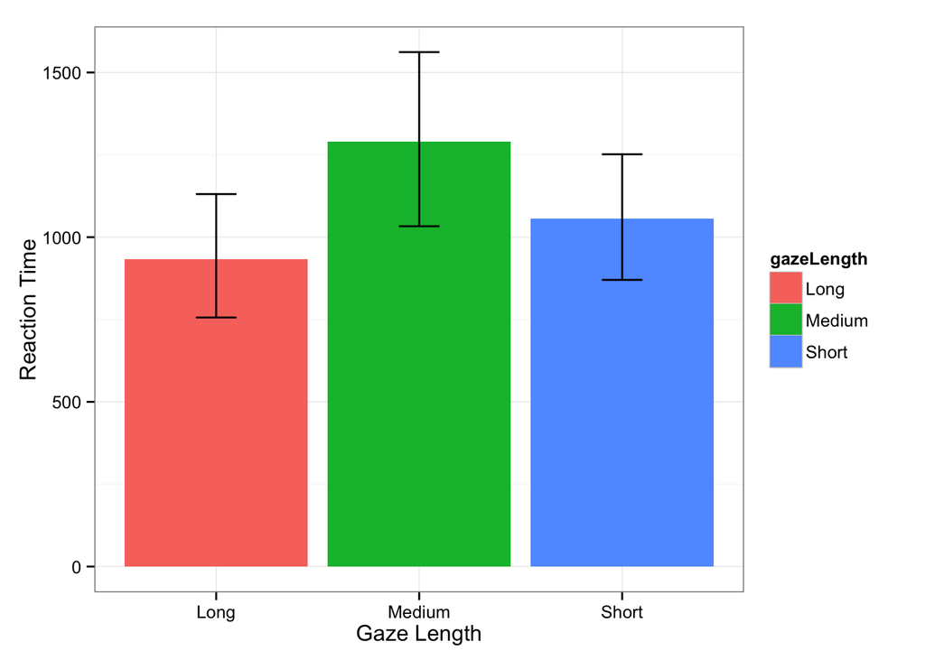

```r
mss.exp.rt <- aggregate(rt ~  gazeLength + subid, data=d.exp, FUN=mean)

# remove +/- 2SD
mss.exp.rt$rt[log(mss.exp.rt$rt) > mean(log(mss.exp.rt$rt)) + 2* sd(log(mss.exp.rt$rt)) |
                log(mss.exp.rt$rt) < mean(log(mss.exp.rt$rt)) - 2* sd(log(mss.exp.rt$rt))] <- NA
ms.exp.rt <- aggregate(rt ~ gazeLength, data=mss.exp.rt, FUN=mean)
ms.exp.rt$rt.cih <- aggregate(rt ~ gazeLength, data=mss.exp.rt, FUN=ci.high)$rt
ms.exp.rt$rt.cil <- aggregate(rt ~ gazeLength, data=mss.exp.rt, FUN=ci.low)$rt

## plots mean reaction time for the different exposure conditions
rt_exp <- ggplot(data=ms.exp.rt, aes(x=gazeLength, y=rt, fill=gazeLength)) +
                geom_bar(stat="identity") +
                geom_errorbar(aes(ymin=rt-rt.cil, ymax=rt+rt.cih,),
                              width=.2) +
                xlab("Gaze Length") +
                ylab("Reaction Time") +
                theme_bw()

rt_exp
```

RT on test trials.

```r
mss.test.rt <- aggregate(rt.x ~  gazeLength + trialType + subid, data=d.test.choseGazeTar, FUN=mean)
# remove +/- 2SD
mss.test.rt$rt[log(mss.test.rt$rt) > mean(log(mss.test.rt$rt)) + 2* sd(log(mss.test.rt$rt)) |
                log(mss.test.rt$rt) < mean(log(mss.test.rt$rt)) - 2* sd(log(mss.test.rt$rt))] <- NA
```

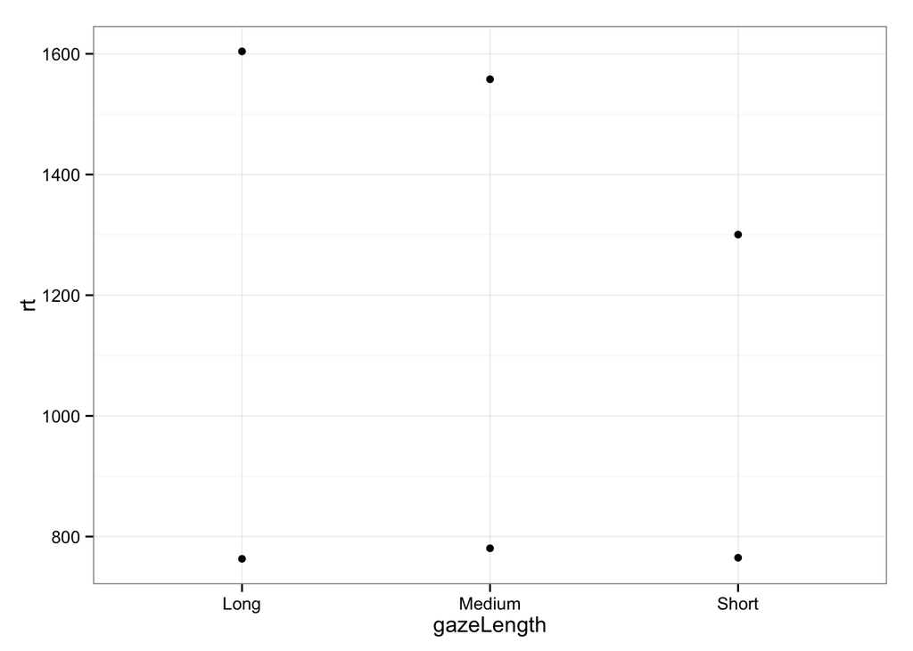

```r
ms.test.rt <- aggregate(rt ~ gazeLength + trialType, data=mss.test.rt, FUN=mean)
ms.test.rt$rt.cih <- aggregate(rt ~ gazeLength + trialType, data=mss.test.rt, FUN=ci.high)$rt
ms.test.rt$rt.cil <- aggregate(rt ~ gazeLength + trialType, data=mss.test.rt, FUN=ci.low)$rt

rt_test_plot <- qplot(data=ms.test.rt,x=gazeLength, y=rt)

rt_test_plot
```

Subset pilot 2 data for analysis.

```r
d1.test <- subset(d1, testTrial==1)                               # test trials
d1.first.trial <- subset(d1, testTrial==1 & first.trial==TRUE)    # first test trial for each sub
d1.exp <- subset(d1, exposureTrial==1)                            # exposure trials
```

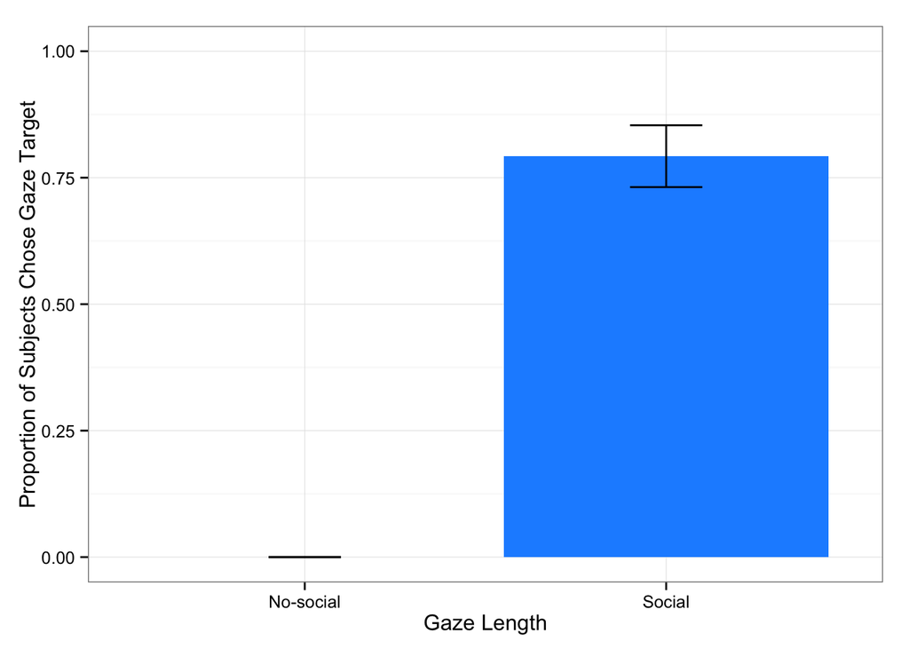

Now subset test trials to include only those on which participants chose the target of gaze on exposure.

```r
d1.choseSocial <- subset(d1.exp, select=c("subid", "itemNum",
                                        "choseSocial", "rt"))   # exposure trials chose gazeTar

d1.test.gazeTar <- merge(d1.test, d1.choseSocial,
                             by=c("subid", "itemNum"),
                             all=TRUE)                          # test trials with exp trial info

d1.test.choseGazeTar <- subset(d1.test.gazeTar,
                              choseSocial == TRUE || condition == "No-social",
                              select=c(subid:rt.y))             # test trials: just chose gazeTar on exp
```

Now plot accuracy on test trials

```
## geom_path: Each group consist of only one observation. Do you need to adjust the group aesthetic?
```

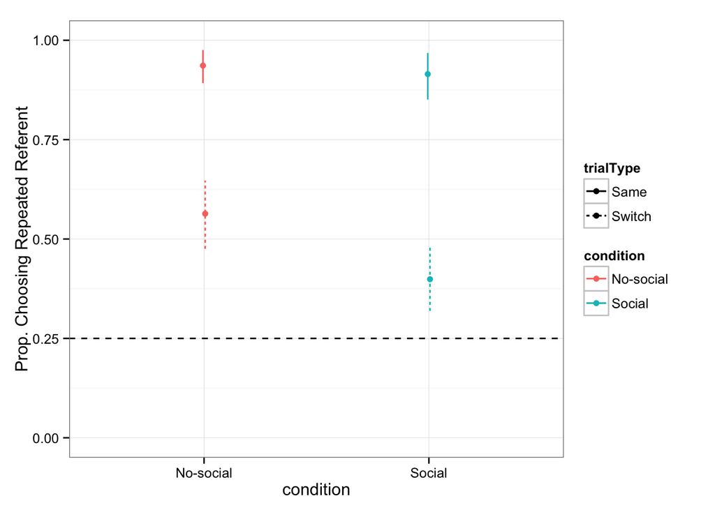

Lmer to see if difference between social and no-social is reliable

```r
m1.l <- glmer(correct ~ trialType * condition + (1|subid),
            data=d1.test.choseGazeTar, family=binomial)
aggregate(correct ~ trialType + condition, d1.test.choseGazeTar, mean)
```

```
##   trialType condition correct
## 1      Same No-social  0.9363
## 2    Switch No-social  0.5637
## 3      Same    Social  0.9149
## 4    Switch    Social  0.3989
```

```r
aggregate(subid ~ trialType + condition, d1.test.choseGazeTar, n.unique)
```

```
##   trialType condition subid
## 1      Same No-social    51
## 2    Switch No-social    51
## 3      Same    Social    47
## 4    Switch    Social    47
```

```r
summary(m1.l)
```

```
## Generalized linear mixed model fit by maximum likelihood (Laplace
##   Approximation) [glmerMod]
##  Family: binomial ( logit )
## Formula: correct ~ trialType * condition + (1 | subid)
##    Data: d1.test.choseGazeTar
##
##      AIC      BIC   logLik deviance df.resid
##    727.9    751.2   -358.9    717.9      779
##
## Scaled residuals:
##    Min     1Q Median     3Q    Max
## -4.495 -0.597  0.223  0.415  3.231
##
## Random effects:
##  Groups Name        Variance Std.Dev.
##  subid  (Intercept) 0.873    0.934
## Number of obs: 784, groups: subid, 98
##
## Fixed effects:
##                                 Estimate Std. Error z value Pr(>|z|)
## (Intercept)                        3.063      0.346    8.86  < 2e-16 ***
## trialTypeSwitch                   -2.750      0.350   -7.87  3.6e-15 ***
## conditionSocial                   -0.375      0.450   -0.83     0.40
## trialTypeSwitch:conditionSocial   -0.423      0.467   -0.91     0.36
## ---
## Signif. codes:  0 '***' 0.001 '**' 0.01 '*' 0.05 '.' 0.1 ' ' 1
##
## Correlation of Fixed Effects:
##             (Intr) trlTyS cndtnS
## trlTypSwtch -0.827
## conditinScl -0.709  0.586
## trlTypSwt:S  0.550 -0.692 -0.792
```

```r
m2.l <- glmer(correct ~ condition +
            (1|subid),
            data=subset(d1.test.choseGazeTar, trialType=="Same"), family=binomial, nAGQ=0)

summary(m2.l)
```

```
## Generalized linear mixed model fit by maximum likelihood (Adaptive
##   Gauss-Hermite Quadrature, nAGQ = 0) [glmerMod]
##  Family: binomial ( logit )
## Formula: correct ~ condition + (1 | subid)
##    Data: subset(d1.test.choseGazeTar, trialType == "Same")
##
##      AIC      BIC   logLik deviance df.resid
##    190.4    202.3    -92.2    184.4      389
##
## Scaled residuals:
##    Min     1Q Median     3Q    Max
## -2.324  0.163  0.163  0.177  1.115
##
## Random effects:
##  Groups Name        Variance Std.Dev.
##  subid  (Intercept) 4.06     2.02
## Number of obs: 392, groups: subid, 98
##
## Fixed effects:
##                 Estimate Std. Error z value Pr(>|z|)
## (Intercept)        3.210      0.467    6.88  6.1e-12 ***
## conditionSocial   -0.242      0.658   -0.37     0.71
## ---
## Signif. codes:  0 '***' 0.001 '**' 0.01 '*' 0.05 '.' 0.1 ' ' 1
##
## Correlation of Fixed Effects:
##             (Intr)
## conditinScl -0.709
```